# A Generative Model for Emotion Dynamics

## Introduction

The aim of this file is to introduce the `GenerativeEmotion` package, a collection of functions that allow users to define and simulate data from the generative model for emotion dynamics, described in “Towards a Generative Model for Emotion Dynamics” (preprint: https://psyarxiv.com/x52ns). The model itself formalizes three core principles:

1. Emotions are reactions to situations
2. Different situations elicit different emotions
3. Situations change over time, thereby producing variation in emotions over time

The model consists of number of discrete and mutually exclusive **Situations** and continuous **Emotions**. Emotions at time $t$ are drawn from a normal distribution whose means are determined by the situation which is present at time $t$. Situations evolve over time according to a Markov model.

The package consists of two main functions. The first function helps specify the behaviour of the generative model itself through a number of *model matrices*. The second function takes these model matrices and *simulates time-series data* from the model.

## Part 1: Specifying the model

The function `model_matrices()` defines the key parameters of the generative model.

- `s` defines the number of distinct situations in the model
- `p` defines the number of different emotions in the model
- The way in which situations evolve over time can be specified either with a custom $s \times s$ Markov transition matrix using the `tmat` argument. Alternatively, this can be done by specifying a staying probability `stay_prob` and a switching probability `switch_prob` which will create a transitiom matrix with all diagonal (staying) elements equal and all off-diagonal (switching) elements equal.
- `means` is a matrix which defines the mean of each emotion in each situation. The format should be a an $s \times p$ matrix, with rows representing situations and columns representing emotions
- `theta` represents the variance of emotions conditional on the situation (i.e., the noise around the mean defined above). At the moment we enforce that these variance terms are uniform across all emotions and situations, and are uncorrelated.

We can specify the model configuration shown in the paper as follows

```r
# number of situations and emotions
s <- 5
p <- 6

# define transition matrix probabilities
stay_prob <- .6
switch_prob <- .1  # (1-stay_prob)/(s-1)

# means of eomtions in each situation
a <- 90
b <- 60
c <- 45

means <- rbind(rep(0,p),
               c(a, b, c,  0  ,  0  ,  0  ),
               c(c, a, b,  0  ,  0  ,  0  ),
               c( 0  ,  0  ,  0  , a, b, c),
               c( 0  ,  0  ,  0  , c, a, b))

# variance of emotions within situations
theta <- 16^2


# create model matrices
model <- model_matrices(s = s,
                     p = p,
                     stay_prob = stay_prob,
                     switch_prob = switch_prob,
                     means = means,
                     theta = theta #, tmat = tmat
)
```

The `model` object now contains the core model matrix objects described in the paper, as well as a number of additional model matrices which can be used for sensitivity analysis and exploring different implications of the model.

For instance the transition matrix of the model is given by

```r
model$tmat
```

```
##      [,1] [,2] [,3] [,4] [,5]
## [1,]  0.6  0.1  0.1  0.1  0.1
## [2,]  0.1  0.6  0.1  0.1  0.1
## [3,]  0.1  0.1  0.6  0.1  0.1
## [4,]  0.1  0.1  0.1  0.6  0.1
## [5,]  0.1  0.1  0.1  0.1  0.6
```

The implied lag-1 auto-regressive and cross-lagged effects are given by

```r
round(model$Phi,2)
```

```
##       [,1]  [,2]  [,3]  [,4]  [,5]  [,6]
## [1,]  0.33  0.05  0.06 -0.01 -0.01 -0.01
## [2,]  0.05  0.27  0.17 -0.01 -0.02 -0.01
## [3,]  0.06  0.17  0.11 -0.01 -0.01 -0.01
## [4,] -0.01 -0.01 -0.01  0.33  0.05  0.06
## [5,] -0.01 -0.02 -0.01  0.05  0.27  0.17
## [6,] -0.01 -0.01 -0.01  0.06  0.17  0.11
```

## Part 2: Simulating from the model

Now that we have specified our model, we can now simulate time-series from it using the `datagen` function.

```r
N <- 500
set.seed(1234)
# sout determines whether situations should be included in the output, or only emotions
dat_sim <- datagen(model, 500, sout = TRUE)
head(dat_sim)
```

[output not shown]

In the output, $X$’s represent emotions, while `st` represents the current situation label. This simulated time series can be analyzed as we would any other empirical time-series. Below we show a plot of two of these simulated emotion variables, along with the situation variable, as shown in the paper.

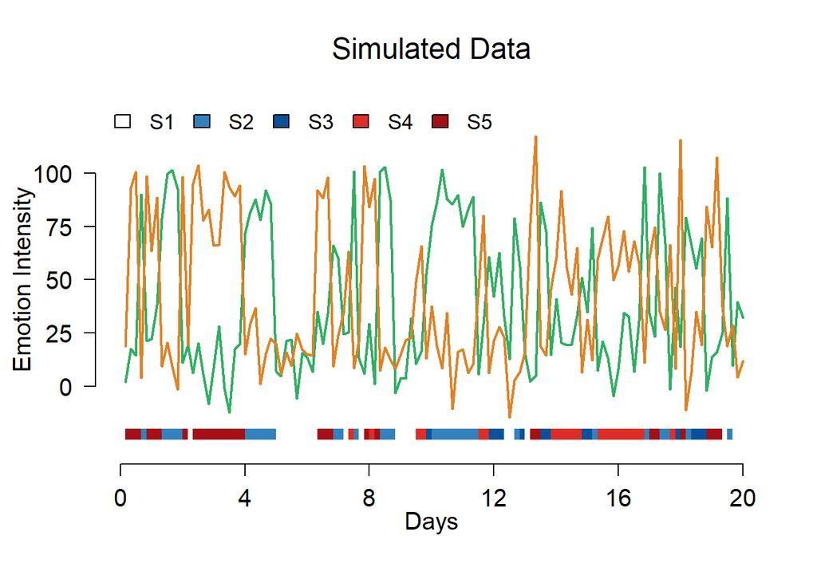